# The dilution of causal strength in abstract chains

Simon Stephan

```r
#tdata.wide <- read.delim("dummy_data.txt", header=TRUE, sep="\t", na.strings="NA", dec=".", strip.white=TRUE)
tdata <- read.delim("Data_Exp_Abstract_Chains.txt", header=TRUE, sep="\t", na.strings="NA", dec=".", strip.white=TRUE)
```

# Results

## Demographics

```r
# demographics

tdata_age <- tdata

min(tdata_age$Age)
```

```
## [1] 18
```

```r
max(tdata_age$Age)
```

```
## [1] 62
```

```r
mean(tdata_age$Age)
```

```
## [1] 32.78
```

```r
sd(tdata_age$Age)
```

```
## [1] 10.06903
```

```r
# 1 = male, 2 = female, 3 = other
table(tdata$Sex)
```

```
##
##  1  2
## 37 63
```

1 = male, 2 = female

# Graphs

For the 4-links chain condition

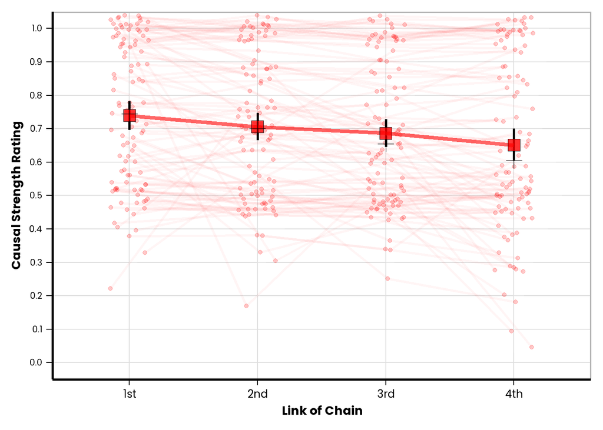

```r
myTheme <- theme(plot.title = element_text(face="bold", size = 22),
        axis.title.x = element_text(face = "bold", size = 20),
        axis.title.y = element_text(face = "bold", size = 20),
        axis.text.x = element_text(size = 18, angle = 0),
        axis.text.y = element_text(size = 14, angle = 0),
        legend.text = element_text(size = 18),
        legend.title = element_text(face = "bold", size = 18),
        strip.text.x = element_text(size = 18),
        #panel.grid.major = element_blank(),
        panel.grid.minor = element_blank(),
        panel.background = element_blank(),
        axis.line.x = element_line(colour = "black"),
        axis.line.y = element_line(colour = "black"),
        axis.text = element_text(colour ="black"),
        axis.ticks = element_line(colour ="black"))


library(see)
tdata_sub <- tdata_4links

## first, turn sID into a factor
tdata_sub$sID <- factor(tdata_sub$sID)

pd <- position_dodge(width = 0.3)

tdata_sub$valueJitter <- jitter(tdata_sub$value, factor = 1, amount = 0.04)

theme_set(theme_light(base_size = 20, base_family = "Poppins"))

# new labes for the facets
#process.labs <- c("Process: Generative", "Process: Preventive")
#names(process.labs) <- c("generative", "preventive")

#valence.labs <- c("Effect valence: Positive", "Effect Valence: Negative")
#names(valence.labs) <- c("positive", "negative")


g <- ggplot(tdata_sub, aes(x=variable, y=valueJitter, group = sID)) +
  guides(fill=FALSE)+
  #facet_grid(Valence ~ Process, labeller = labeller(Process = process.labs, Valence = valence.labs))+
  #ggtitle("Subjects' causal srength ratings") +
  scale_y_continuous(limits = c(-0.05, 1.05), breaks=seq(0, 1, 0.1), expand = c(0,0)) +
  #scale_x_discrete(labels=c("Downward chain", "Upward chain")) +
  #stat_summary(fun.y = mean, geom = "bar", position = "dodge", colour = "black", alpha =0.5) +
  geom_violinhalf(aes(y = value, group = variable), color = NA, position=position_dodge(1), alpha = 0.2)+
  geom_line(position = pd, color = "red", size = 1, alpha=0.04) +
  geom_point(position = pd, alpha = 0.2, fill = "red", color = "red") +
  stat_summary(aes(y = value,group=1), fun.data = mean_cl_boot, geom = "errorbar", width = 0, size = 1) +
  stat_summary(aes(y = value,group=1), fun.y=mean, colour="red", geom="line",group=1, size = 1.5, linetype = "solid", alpha = 0.6)+
  stat_summary(aes(y = value,group=1), fun.y=mean, geom="point", color = "black", fill = "red", shape = 22, size = 5, group=1, alpha = 0.8)+
  stat_summary(aes(y = value,group=1), fun.y=median, geom="point", color = "black", shape = 3, size = 4, group=1, alpha = 1, position = position_dodge(width = 0.5))+
  labs(x = "Link of Chain", y = "Causal Strength Rating") +
  #scale_color_manual(name = "Entity",values=c("#fc9272", "#3182bd"))+
  #scale_fill_manual(name = "Entity",values=c("#fc9272", "#3182bd"))+
  theme(legend.position = "none")+
  myTheme
g
```

```r
#ggsave("results_lines4.svg",width=7,height=6)
#ggsave("results_lines4.pdf",width=7,height=6)
```

For the 8-links chain condition

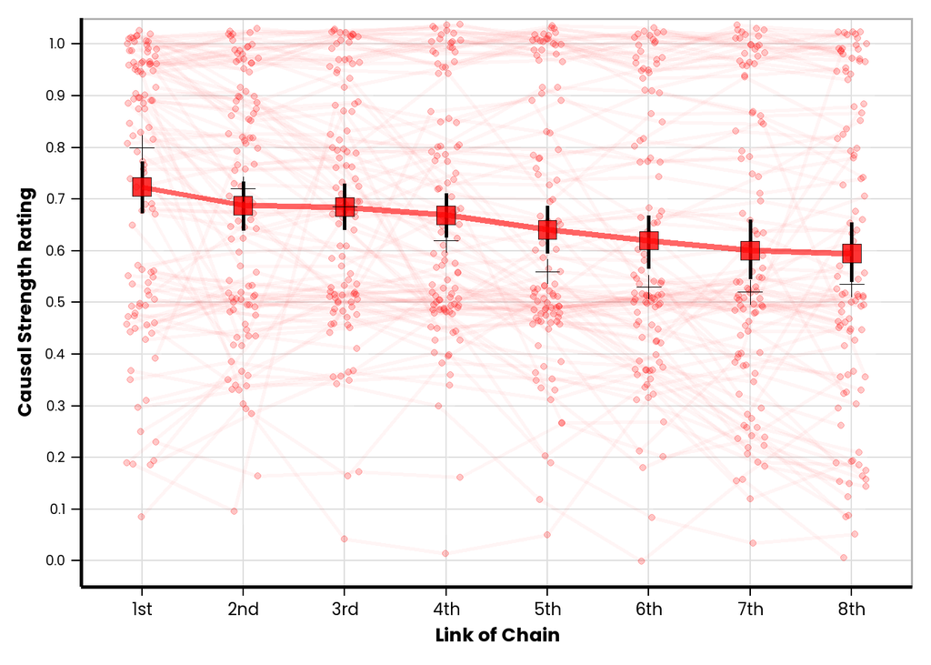

```r
myTheme <- theme(plot.title = element_text(face="bold", size = 22),
        axis.title.x = element_text(face = "bold", size = 20),
        axis.title.y = element_text(face = "bold", size = 20),
        axis.text.x = element_text(size = 18, angle = 0),
        axis.text.y = element_text(size = 14, angle = 0),
        legend.text = element_text(size = 18),
        legend.title = element_text(face = "bold", size = 18),
        strip.text.x = element_text(size = 18),
        #panel.grid.major = element_blank(),
        panel.grid.minor = element_blank(),
        panel.background = element_blank(),
        axis.line.x = element_line(colour = "black"),
        axis.line.y = element_line(colour = "black"),
        axis.text = element_text(colour ="black"),
        axis.ticks = element_line(colour ="black"))


library(see)

tdata_sub <- tdata_8links

## first, turn sID into a factor
tdata_sub$sID <- factor(tdata_sub$sID)

pd <- position_dodge(width = 0.3)

tdata_sub$valueJitter <- jitter(tdata_sub$value, factor = 1, amount = 0.04)

theme_set(theme_light(base_size = 20, base_family = "Poppins"))

# new labes for the facets
#process.labs <- c("Process: Generative", "Process: Preventive")
#names(process.labs) <- c("generative", "preventive")

#valence.labs <- c("Effect valence: Positive", "Effect Valence: Negative")
#names(valence.labs) <- c("positive", "negative")


g <- ggplot(tdata_sub, aes(x=variable, y=valueJitter, group = sID)) +
  guides(fill=FALSE)+
  #facet_grid(Valence ~ Process, labeller = labeller(Process = process.labs, Valence = valence.labs))+
  #ggtitle("Subjects' causal srength ratings") +
  scale_y_continuous(limits = c(-0.05, 1.05), breaks=seq(0, 1, 0.1), expand = c(0,0)) +
  #scale_x_discrete(labels=c("Downward chain", "Upward chain")) +
  #stat_summary(fun.y = mean, geom = "bar", position = "dodge", colour = "black", alpha =0.5) +
  geom_violinhalf(aes(y = value, group = variable), color = NA, position=position_dodge(1), alpha = 0.2)+
  geom_line(position = pd, color = "red", size = 1, alpha=0.04) +
  geom_point(position = pd, alpha = 0.2, fill = "red", color = "red") +
  stat_summary(aes(y = value,group=1), fun.data = mean_cl_boot, geom = "errorbar", width = 0, size = 1) +
  stat_summary(aes(y = value,group=1), fun.y=mean, colour="red", geom="line",group=1, size = 1.5, linetype = "solid", alpha = 0.6)+
  stat_summary(aes(y = value,group=1), fun.y=mean, geom="point", color = "black", fill = "red", shape = 22, size = 5, group=1, alpha = 0.8)+
  stat_summary(aes(y = value,group=1), fun.y=median, geom="point", color = "black", shape = 3, size = 4, group=1, alpha = 1, position = position_dodge(width = 0.5))+
  labs(x = "Link of Chain", y = "Causal Strength Rating") +
  #scale_color_manual(name = "Entity",values=c("#fc9272", "#3182bd"))+
  #scale_fill_manual(name = "Entity",values=c("#fc9272", "#3182bd"))+
  theme(legend.position = "none")+
  myTheme
g
```

```r
#ggsave("results_lines8.svg",width=7,height=6)
#ggsave("results_lines8.pdf",width=7,height=6)
```

# Descriptive Stats

8-links chain condition:

[output not shown]

4-links chain condition:

```r
tdata_sub <- tdata_4links

by(tdata_sub$value, list(tdata_sub$variable), stat.desc , basic = FALSE)
```

```
## : 1st
##       median         mean      SE.mean CI.mean.0.95          var      std.dev
##   0.74500000   0.73940000   0.02183493   0.04332523   0.04767640   0.21834927
##     coef.var
##   0.29530602
## ------------------------------------------------------------
## : 2nd
##       median         mean      SE.mean CI.mean.0.95          var      std.dev
##   0.70000000   0.70620000   0.02132565   0.04231472   0.04547834   0.21325652
##     coef.var
##   0.30197751
## ------------------------------------------------------------
## : 3rd
##       median         mean      SE.mean CI.mean.0.95          var      std.dev
##   0.65500000   0.68650000   0.02091077   0.04149149   0.04372601   0.20910765
##     coef.var
##   0.30459964
## ------------------------------------------------------------
## : 4th
##       median         mean      SE.mean CI.mean.0.95          var      std.dev
##   0.60500000   0.65100000   0.02519319   0.04998876   0.06346970   0.25193193
##     coef.var
##   0.38699221
```

# Inferential Statistics

8-links chain:

Repeated-Measures ANOVA

```r
library(afex)
library(emmeans)
tdata_sub <- tdata_8links
a1 <- aov_car(value ~ variable + Error(sID/(variable)), tdata_sub)
a1
```

```
## Anova Table (Type 3 tests)
##
## Response: value
##     Effect           df  MSE         F  ges p.value
## 1 variable 1.94, 192.06 0.06 12.68 *** .028   <.001
## ---
## Signif. codes:  0 '***' 0.001 '**' 0.01 '*' 0.05 '+' 0.1 ' ' 1
##
## Sphericity correction method: GG
```

Main effect of link of chain (“variable”).

Is there a negative linear trend? Conduct a polynomial contrast analysis:

```r
# Polynomial Contrasts
#library(Rcmdr)
# Quantitative Trend analysis

contrasts(tdata_sub$variable) <- "contr.poly" # define contrast coefficients

Trend <- aov(value ~ variable, data=tdata_sub)
summary.lm(Trend)
```

```
##
## Call:
## aov(formula = value ~ variable, data = tdata_sub)
##
## Residuals:
##     Min      1Q  Median      3Q     Max
## -0.6346 -0.1898 -0.0376  0.2418  0.4054
##
## Coefficients:
##              Estimate Std. Error t value Pr(>|t|)
## (Intercept)  0.652538   0.009037  72.204  < 2e-16 ***
## variable.L  -0.120210   0.025562  -4.703 3.03e-06 ***
## variable.Q   0.004143   0.025562   0.162    0.871
## variable.C   0.004327   0.025562   0.169    0.866
## variable^4   0.014066   0.025562   0.550    0.582
## variable^5  -0.009165   0.025562  -0.359    0.720
## variable^6   0.004191   0.025562   0.164    0.870
## variable^7   0.001733   0.025562   0.068    0.946
## ---
## Signif. codes:  0 '***' 0.001 '**' 0.01 '*' 0.05 '.' 0.1 ' ' 1
##
## Residual standard error: 0.2556 on 792 degrees of freedom
## Multiple R-squared:  0.02778,    Adjusted R-squared:  0.01919
## F-statistic: 3.233 on 7 and 792 DF,  p-value: 0.002179
```

Yes, the only sign. quantitative trend is a negative linear trend (see “variable.L”).

Now for the 4-links chain:

Repeated-Measures ANOVA:

```r
# now the same analysis for the condition with 4 links

library(afex)
library(emmeans)
tdata_sub <- tdata_4links
a2 <- aov_car(value ~ variable + Error(sID/(variable)), tdata_sub)
a2
```

```
## Anova Table (Type 3 tests)
##
## Response: value
##     Effect           df  MSE         F  ges p.value
## 1 variable 1.91, 188.82 0.02 11.95 *** .020   <.001
## ---
## Signif. codes:  0 '***' 0.001 '**' 0.01 '*' 0.05 '+' 0.1 ' ' 1
##
## Sphericity correction method: GG
```

Main effect of Link of chain.

Negative Trend?

```r
# Polynomial Contrasts
#library(Rcmdr)
# Quantitative Trend analysis

contrasts(tdata_sub$variable) <- "contr.poly" # define contrast coefficients

Trend <- aov(value ~ variable, data=tdata_sub)
summary.lm(Trend)
```

```
##
## Call:
## aov(formula = value ~ variable, data = tdata_sub)
##
## Residuals:
##     Min      1Q  Median      3Q     Max
## -0.6210 -0.1872 -0.0194  0.2313  0.3490
##
## Coefficients:
##              Estimate Std. Error t value Pr(>|t|)
## (Intercept)  0.695775   0.011190  62.178  < 2e-16 ***
## variable.L  -0.063706   0.022380  -2.847  0.00465 **
## variable.Q  -0.001150   0.022380  -0.051  0.95904
## variable.C  -0.006552   0.022380  -0.293  0.76987
## ---
## Signif. codes:  0 '***' 0.001 '**' 0.01 '*' 0.05 '.' 0.1 ' ' 1
##
## Residual standard error: 0.2238 on 396 degrees of freedom
## Multiple R-squared:  0.02027,    Adjusted R-squared:  0.01284
## F-statistic:  2.73 on 3 and 396 DF,  p-value: 0.04364
```

Yes.

A more compact list of the means:

8-links chain

```r
# for 8 links

tdata_sub <- tdata_8links

# same ANOVA as before
lmeModel <- lmer(value ~ variable + (1|sID), data=tdata_sub)

# follow-up analysis

ls1 <- lsmeans(a1, c("variable")) # joint evaluation (basically gives the same table)
ls1
```

```
##  variable lsmean     SE  df lower.CL upper.CL
##  X1st      0.723 0.0256 162    0.673    0.774
##  X2nd      0.688 0.0256 162    0.637    0.738
##  X3rd      0.685 0.0256 162    0.634    0.735
##  X4th      0.669 0.0256 162    0.618    0.719
##  X5th      0.641 0.0256 162    0.590    0.691
##  X6th      0.620 0.0256 162    0.569    0.670
##  X7th      0.601 0.0256 162    0.550    0.651
##  X8th      0.595 0.0256 162    0.544    0.645
##
## Warning: EMMs are biased unless design is perfectly balanced
## Confidence level used: 0.95
```

Our measure for dilution: Difference between first and last link.

8-links chain contrast:

```r
# contrast 1st vs. 8th link

tdata_18 <- subset(tdata_8links, variable == "1st" | variable == "8th")
tdata_sub <- tdata_18

a1 <- aov_car(value ~ variable + Error(sID/(variable)), tdata_sub)

# contrast

ls2 <- lsmeans(a1, c("variable")) # group means by between-condition
ls2
```

```
##  variable lsmean    SE  df lower.CL upper.CL
##  X1st      0.723 0.028 178    0.668    0.779
##  X8th      0.595 0.028 178    0.539    0.650
##
## Warning: EMMs are biased unless design is perfectly balanced
## Confidence level used: 0.95
```

```r
# simple main effects
t <- pairs(ls2) # compares rep-measure differences separately for each between-factor level
t
```

```
##  contrast    estimate     SE df t.ratio p.value
##  X1st - X8th    0.129 0.0323 99 3.989   0.0001
```

Yes, the contrast is significant (see “contrast” output).

Compute a 95 CI for the difference:

```r
confint(t, adjust = "none")
```

```
##  contrast    estimate     SE df lower.CL upper.CL
##  X1st - X8th    0.129 0.0323 99   0.0647    0.193
##
## Confidence level used: 0.95
```

Manually:

```r
t <- qt(0.975, 99, lower.tail = TRUE, log.p = FALSE) # get the correct t-Value


effect <- "Mdiff"
Mdiff <- 0.129  # the estimated difference from the output above
SE <- 0.0323  # its SE
CI <- SE*t
CI_low <- Mdiff - CI
CI_up <- Mdiff + CI

Mdiff
```

```
## [1] 0.129
```

```r
CI_low
```

```
## [1] 0.06490979
```

```r
CI_up
```

```
## [1] 0.1930902
```

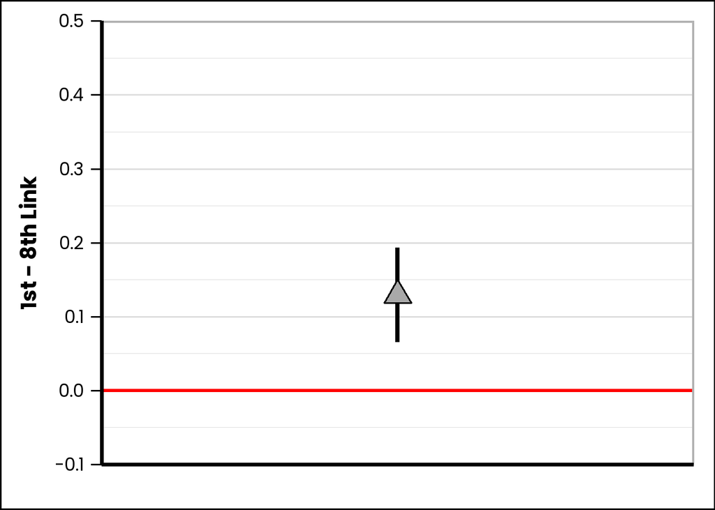

```r
# Plot

myTheme <- theme(plot.title = element_text(face="bold", size = 22),
        axis.title.x = element_text(face = "bold", size = 20),
        axis.title.y = element_text(face = "bold", size = 20),
        axis.text.x = element_text(size = 18, angle = 0),
        axis.text.y = element_text(size = 25, angle = 0),
        legend.text = element_text(size = 18),
        legend.title = element_text(face = "bold", size = 18),
        strip.text.x = element_text(size = 18),
        #panel.grid.major = element_blank(),
        #panel.grid.minor = element_blank(),
        #panel.background = element_blank(),
        axis.line.x = element_line(colour = "black"),
        axis.line.y = element_line(colour = "black"),
        axis.text = element_text(colour ="black"),
        axis.ticks = element_line(colour ="black"))

theme_set(theme_light(base_size = 30, base_family = "Poppins"))



barchart <- ggplot()+
  myTheme+
  #guides(fill=FALSE)+
  #facet_wrap(~Latency + SampleSize, ncol=2)+
  #ggtitle("Mean difference (95% CI)") +
  #coord_cartesian(ylim=c(-0.1,2)) +
  scale_y_continuous(limits = c(-0.1, 0.5), breaks=seq(-0.1, 0.5, 0.1), expand = c(0,0)) +
  scale_x_discrete(labels=c("r")) +
  #annotate("rect", xmin=1.7, xmax=2.3, ymin=0.95, ymax=1.05, color="#31a354", fill = "white", size = 1) +
  #stat_summary(fun.y=mean, colour="grey20", geom="point", shape = 21, size = 3)+
  #stat_summary(fun.y = mean, geom = "bar", position = "dodge", colour = "black")+
  #stat_summary(fun.data = mean_cl_boot, geom = "errorbar", position = position_dodge(width = 0.90), width = 0.2) +
  #geom_jitter(width = 0.3, height = 0.02, alpha = 0.6, colour = "red") +
  #ggtitle("Means (95% bootstr. CIs)") +
  #theme(axis.text.x = element_text(size = 10, angle = 0, hjust = 0.5))+
  labs(x= "", y = "1st - 8th Link") +
  #scale_color_manual(values=c("#005083",  "#f0b64d"))# +
  #scale_fill_manual(values=c("#969696",  "#969696"))
  #annotate("point", x = 1, y = 100, colour = "firebrick", size = 2)+
  #annotate(xmin = -Inf, xmax = Inf, ymin = 4.77-1.96*0.297, ymax = 4.77+1.96*0.297, geom = "rect", alpha = 0.2, fill = "firebrick")+
  #annotate(xmin = -Inf, xmax = Inf, ymin = 5.02-1.96*0.372, ymax = 5.02+1.96*0.372, geom = "rect", alpha = 0.2, fill = "blue")+
  #annotate(geom = "hline",yintercept = 100, y = 100, color = "red")+
  annotate("pointrange", x = 1, y = Mdiff, ymin = CI_low, ymax = CI_up, colour = "black", size = 1.5, shape = 24, fill = "darkgrey")+
  #annotate("pointrange", x = 2, y = 5.02, ymin = 5.02-1.96*0.372, ymax = 5.02+1.96*0.372, colour = "blue", size = 0.8, shape = 15)+
  #annotate("text", x = 0.5, y = 2.6, family = "Poppins", size = 6, color = "gray20", label = "Impfeffekt")+
  #geom_curve(aes(x = 0.5, y = 3, xend = 0.9, yend = 4),arrow = arrow(length = unit(0.03, "npc")),color = "gray20", curvature = +0.2)+
  #annotate("text", x = 1.8, y = 2.6, family = "Poppins", size = 6, color = "gray20", label = "Dosierungseffekt")+
  #geom_curve(aes(x = 1.8, y = 3, xend = 2, yend = 4),arrow = arrow(length = unit(0.03, "npc")),color = "gray20", curvature = +0.2)+
  annotate(geom = "hline",yintercept = 0, y = 0, color = "red", size = 1.2)+
  theme(plot.background = element_rect(
    fill = "white",
    colour = "black",
    size = 1
  ),
    axis.title.y = element_text(size = 30))
barchart
```

```r
#ggsave("delta_1st_vs_8th.svg",width=2.5,height=4)
ggsave("delta_1st_vs_8th.pdf",width=2.5,height=4)
```

Compute Cohen’s for the contrast between the first and the last link.

8-Links Chain:

```r
dat <- tdata_18


# since we have a repeated-meausres design, we now need the correlations of the ratings
library(dplyr) # for pipe operator
dat_wide <- spread(tdata_18, variable, value)
colnames(dat_wide) <- c("sID", "Links", "first", "last")
dat_wide -> t
r <- cor(t$first, t$last)
r
```

```
## [1] 0.3381342
```

```r
# now compute ES and SE and CI of it
# using the esc package because it gives SE of the ES directly
library(esc)

# get means and sds
m1 <- dat %>%
          filter(variable == "1st")%>%
          summarize(Mean1 = mean(value))

sd1 <- dat %>%
          filter(variable == "1st")%>%
          summarize(SD1 = sd(value))


m2 <- dat %>%
          filter(variable == "8th")%>%
          summarize(Mean2 = mean(value))

sd2 <- dat %>%
          filter(variable == "8th")%>%
          summarize(SD2 = sd(value))



esc_mean_sd(
  grp1m = m1[,1], grp1sd = sd1[,1], grp1n = length(dat$sID)/2,
  grp2m = m2[,1], grp2sd = sd2[,1], grp2n = length(dat$sID)/2,
  r = r,
  es.type = "d"
)
```

```
##
## Effect Size Calculation for Meta Analysis
##
##      Conversion: mean and sd (within-subject) to effect size d
##     Effect Size:   0.3989
##  Standard Error:   0.1428
##        Variance:   0.0204
##        Lower CI:   0.1190
##        Upper CI:   0.6788
##          Weight:  49.0250
```

Now the same for the 4-links chain:

```r
library(afex)
library(emmeans)
tdata_sub <- tdata_4links
a2 <- aov_car(value ~ variable + Error(sID/(variable)), tdata_sub)


tdata_sub <- tdata_4links

# same ANOVA as before
lmeModel <- lmer(value ~ variable + (1|sID), data=tdata_sub)


ls1 <- lsmeans(a2, c("variable")) # joint evaluation (basically gives the same table)
ls1
```

```
##  variable lsmean     SE  df lower.CL upper.CL
##  X1st      0.739 0.0224 142    0.695    0.784
##  X2nd      0.706 0.0224 142    0.662    0.750
##  X3rd      0.686 0.0224 142    0.642    0.731
##  X4th      0.651 0.0224 142    0.607    0.695
##
## Warning: EMMs are biased unless design is perfectly balanced
## Confidence level used: 0.95
```

Contrast for first vs. last link:

```r
# contrast 1st vs. 8th link

tdata_14 <- subset(tdata_4links, variable == "1st" | variable == "4th")
tdata_sub <- tdata_14

a1 <- aov_car(value ~ variable + Error(sID/(variable)), tdata_sub)


ls2 <- lsmeans(a1, c("variable")) # group means by between-condition
ls2
```

```
##  variable lsmean     SE  df lower.CL upper.CL
##  X1st      0.739 0.0236 146    0.693    0.786
##  X4th      0.651 0.0236 146    0.604    0.698
##
## Warning: EMMs are biased unless design is perfectly balanced
## Confidence level used: 0.95
```

```r
# simple main effects
t <- pairs(ls2) # compares rep-measure differences separately for each between-factor level
t
```

```
##  contrast    estimate     SE df t.ratio p.value
##  X1st - X4th   0.0884 0.0212 99 4.167   0.0001
```

also significant.

```r
confint(t, adjust = "none")
```

```
##  contrast    estimate     SE df lower.CL upper.CL
##  X1st - X4th   0.0884 0.0212 99   0.0463     0.13
##
## Confidence level used: 0.95
```

Confidence intervall for the difference:

```r
t <- qt(0.975, 99, lower.tail = TRUE, log.p = FALSE)
#t

effect <- "Mdiff"
Mdiff <- 0.0884
SE <- 0.0212
CI <- SE*t
CI_low <- Mdiff - CI
CI_up <- Mdiff + CI

Mdiff
```

```
## [1] 0.0884
```

```r
CI_low
```

```
## [1] 0.0463346
```

```r
CI_up
```

```
## [1] 0.1304654
```

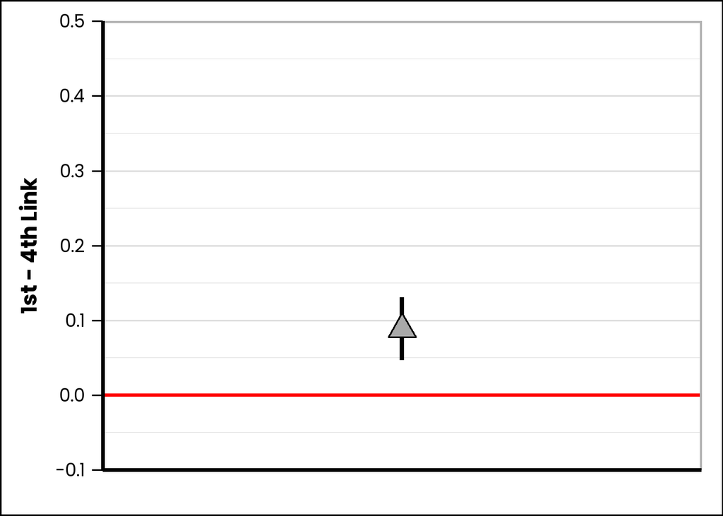

```r
# Plot

myTheme <- theme(plot.title = element_text(face="bold", size = 22),
        axis.title.x = element_text(face = "bold", size = 20),
        axis.title.y = element_text(face = "bold", size = 20),
        axis.text.x = element_text(size = 18, angle = 0),
        axis.text.y = element_text(size = 25, angle = 0),
        legend.text = element_text(size = 18),
        legend.title = element_text(face = "bold", size = 18),
        strip.text.x = element_text(size = 18),
        #panel.grid.major = element_blank(),
        #panel.grid.minor = element_blank(),
        #panel.background = element_blank(),
        axis.line.x = element_line(colour = "black"),
        axis.line.y = element_line(colour = "black"),
        axis.text = element_text(colour ="black"),
        axis.ticks = element_line(colour ="black"))

theme_set(theme_light(base_size = 30, base_family = "Poppins"))



barchart <- ggplot()+
  myTheme+
  #guides(fill=FALSE)+
  #facet_wrap(~Latency + SampleSize, ncol=2)+
  #ggtitle("Mean difference (95% CI)") +
  #coord_cartesian(ylim=c(-0.1,2)) +
  scale_y_continuous(limits = c(-0.1, 0.5), breaks=seq(-0.1, 0.5, 0.1), expand = c(0,0)) +
  scale_x_discrete(labels=c("r")) +
  #annotate("rect", xmin=1.7, xmax=2.3, ymin=0.95, ymax=1.05, color="#31a354", fill = "white", size = 1) +
  #stat_summary(fun.y=mean, colour="grey20", geom="point", shape = 21, size = 3)+
  #stat_summary(fun.y = mean, geom = "bar", position = "dodge", colour = "black")+
  #stat_summary(fun.data = mean_cl_boot, geom = "errorbar", position = position_dodge(width = 0.90), width = 0.2) +
  #geom_jitter(width = 0.3, height = 0.02, alpha = 0.6, colour = "red") +
  #ggtitle("Means (95% bootstr. CIs)") +
  #theme(axis.text.x = element_text(size = 10, angle = 0, hjust = 0.5))+
  labs(x= "", y = "1st - 4th Link") +
  #scale_color_manual(values=c("#005083",  "#f0b64d"))# +
  #scale_fill_manual(values=c("#969696",  "#969696"))
  #annotate("point", x = 1, y = 100, colour = "firebrick", size = 2)+
  #annotate(xmin = -Inf, xmax = Inf, ymin = 4.77-1.96*0.297, ymax = 4.77+1.96*0.297, geom = "rect", alpha = 0.2, fill = "firebrick")+
  #annotate(xmin = -Inf, xmax = Inf, ymin = 5.02-1.96*0.372, ymax = 5.02+1.96*0.372, geom = "rect", alpha = 0.2, fill = "blue")+
  #annotate(geom = "hline",yintercept = 100, y = 100, color = "red")+
  annotate("pointrange", x = 1, y = Mdiff, ymin = CI_low, ymax = CI_up, colour = "black", size = 1.5, shape = 24, fill = "darkgrey")+
  #annotate("pointrange", x = 2, y = 5.02, ymin = 5.02-1.96*0.372, ymax = 5.02+1.96*0.372, colour = "blue", size = 0.8, shape = 15)+
  #annotate("text", x = 0.5, y = 2.6, family = "Poppins", size = 6, color = "gray20", label = "Impfeffekt")+
  #geom_curve(aes(x = 0.5, y = 3, xend = 0.9, yend = 4),arrow = arrow(length = unit(0.03, "npc")),color = "gray20", curvature = +0.2)+
  #annotate("text", x = 1.8, y = 2.6, family = "Poppins", size = 6, color = "gray20", label = "Dosierungseffekt")+
  #geom_curve(aes(x = 1.8, y = 3, xend = 2, yend = 4),arrow = arrow(length = unit(0.03, "npc")),color = "gray20", curvature = +0.2)+
  annotate(geom = "hline",yintercept = 0, y = 0, color = "red", size = 1.2)+
  theme(plot.background = element_rect(
    fill = "white",
    colour = "black",
    size = 1
  ),
    axis.title.y = element_text(size = 30))
barchart
```

```r
#ggsave("delta_1st_vs_4th.svg",width=2.5,height=4)
ggsave("delta_1st_vs_4th.pdf",width=2.5,height=4)
```

What Cohen’s d does this correspond to?

4 Links Chain:

```r
dat <- tdata_14


# since we have a repeated-meausres design, we now need the correlations of the ratings
library(dplyr) # for pipe operator
dat_wide <- spread(tdata_14, variable, value)
colnames(dat_wide) <- c("sID", "Links", "first", "last")
dat_wide -> t
r <- cor(t$first, t$last)
r
```

```
## [1] 0.60127
```

```r
# now compute ES and SE and CI of it
# using the esc package because it gives SE of the ES directly
library(esc)

# get means and sds
m1 <- dat %>%
          filter(variable == "1st")%>%
          summarize(Mean1 = mean(value))

sd1 <- dat %>%
          filter(variable == "1st")%>%
          summarize(SD1 = sd(value))


m2 <- dat %>%
          filter(variable == "4th")%>%
          summarize(Mean2 = mean(value))

sd2 <- dat %>%
          filter(variable == "4th")%>%
          summarize(SD2 = sd(value))



esc_mean_sd(
  grp1m = m1[,1], grp1sd = sd1[,1], grp1n = length(dat$sID)/2,
  grp2m = m2[,1], grp2sd = sd2[,1], grp2n = length(dat$sID)/2,
  r = r,
  es.type = "d"
)
```

```
##
## Effect Size Calculation for Meta Analysis
##
##      Conversion: mean and sd (within-subject) to effect size d
##     Effect Size:   0.4167
##  Standard Error:   0.1429
##        Variance:   0.0204
##        Lower CI:   0.1366
##        Upper CI:   0.6969
##          Weight:  48.9376
```

# Interaction

This is exploratory

# Graph of interaction

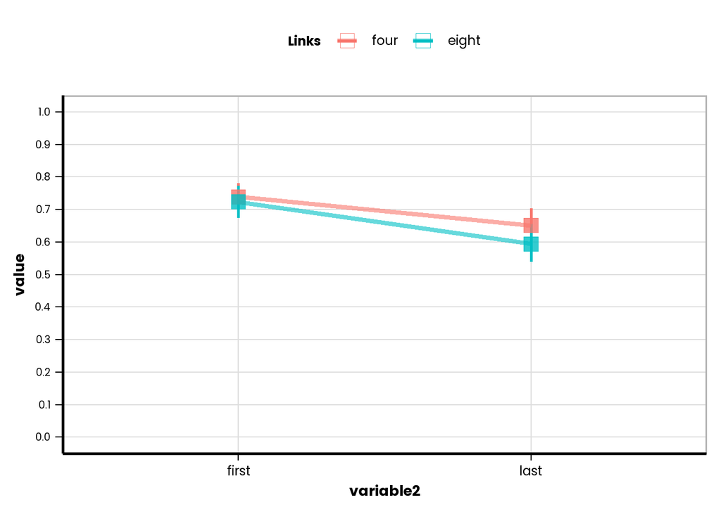

```r
myTheme <- theme(plot.title = element_text(face="bold", size = 22),
        axis.title.x = element_text(face = "bold", size = 20),
        axis.title.y = element_text(face = "bold", size = 20),
        axis.text.x = element_text(size = 18, angle = 0),
        axis.text.y = element_text(size = 14, angle = 0),
        legend.text = element_text(size = 18),
        legend.title = element_text(face = "bold", size = 18),
        strip.text.x = element_text(size = 18),
        #panel.grid.major = element_blank(),
        panel.grid.minor = element_blank(),
        panel.background = element_blank(),
        axis.line.x = element_line(colour = "black"),
        axis.line.y = element_line(colour = "black"),
        axis.text = element_text(colour ="black"),
        axis.ticks = element_line(colour ="black"))


library(see)

tdata_sub <- tdata_1814

## first, turn sID into a factor
tdata_sub$sID <- factor(tdata_sub$sID)

pd <- position_dodge(width = 0.3)

tdata_sub$valueJitter <- jitter(tdata_sub$value, factor = 1, amount = 0.04)

theme_set(theme_light(base_size = 20, base_family = "Poppins"))

# new labes for the facets
#process.labs <- c("Process: Generative", "Process: Preventive")
#names(process.labs) <- c("generative", "preventive")

#valence.labs <- c("Effect valence: Positive", "Effect Valence: Negative")
#names(valence.labs) <- c("positive", "negative")


g <- ggplot(tdata_sub, aes(x=variable2, y=value, color = Links, fill = Links)) +
  guides(fill=FALSE)+
  #facet_grid(Valence ~ Process, labeller = labeller(Process = process.labs, Valence = valence.labs))+
  #ggtitle("Subjects' causal srength ratings") +
  scale_y_continuous(limits = c(-0.05, 1.05), breaks=seq(0, 1, 0.1), expand = c(0,0)) +
  #scale_x_discrete(labels=c("Downward chain", "Upward chain")) +
  #stat_summary(fun.y = mean, geom = "bar", position = "dodge", colour = "black", alpha =0.5) +
  stat_summary(aes(group = Links, fill = Links, color = Links), fun.data = mean_cl_boot, geom = "errorbar", width = 0, size = 1) +
  stat_summary(aes(group = Links, fill = Links, color = Links), fun.y=mean, geom="line", size = 1.5, linetype = "solid", alpha = 0.6)+
  stat_summary(aes(group = Links, fill = Links, color = Links), fun.y=mean, geom="point", shape = 22, size = 5, group=1, alpha = 0.8)+
  #stat_summary(fun.y=median, geom="point", color = "black", shape = 3, size = 4, group=1, alpha = 1, position = position_dodge(width = 0.5))+
  #labs(x = "Link of Chain", y = "Causal Strength Rating") +
  #scale_color_manual(name = "Entity",values=c("#fc9272", "#3182bd"))+
  #scale_fill_manual(name = "Entity",values=c("#fc9272", "#3182bd"))+
  theme(legend.position = "top")+
  myTheme
g
```

```r
#ggsave("results_lines8.svg",width=7,height=6)
#ggsave("results_lines8.pdf",width=7,height=6)
```

Indeed, the longer chain seems to lead to more dilution (but the effect is very weak).

ANOVA:

```r
a1 <- aov_car(value ~ Links + variable2 + Error(sID/(Links+variable2)), tdata_sub)
a1
```

```
## Anova Table (Type 3 tests)
##
## Response: value
##            Effect    df  MSE         F  ges p.value
## 1           Links 1, 99 0.02   7.29 ** .005    .008
## 2       variable2 1, 99 0.06 19.14 *** .043   <.001
## 3 Links:variable2 1, 99 0.01    3.13 + .002    .080
## ---
## Signif. codes:  0 '***' 0.001 '**' 0.01 '*' 0.05 '+' 0.1 ' ' 1
```

Not signifiant.

Directed Contrast for this interaction:

```r
###############
# a conditional analysis

ls2 <- lsmeans(a1, c("Links","variable2")) # group means by between-condition
ls2
```

```
##  Links variable2 lsmean     SE  df lower.CL upper.CL
##  four  first      0.739 0.0259 203    0.688    0.790
##  eight first      0.723 0.0259 203    0.672    0.774
##  four  last       0.651 0.0259 203    0.600    0.702
##  eight last       0.595 0.0259 203    0.544    0.646
##
## Warning: EMMs are biased unless design is perfectly balanced
## Confidence level used: 0.95
```

```r
# simple main effects
pairs(pairs(ls2),adjust = "none") # compares rep-measure differences separately for each between-factor level
```

```
##  contrast                                                estimate     SE  df
##  (four first - eight first) - (four first - four last)    -0.0724 0.0282 152
##  (four first - eight first) - (four first - eight last)   -0.1288 0.0273 139
##  (four first - eight first) - (eight first - four last)   -0.0564 0.0383 233
##  (four first - eight first) - (eight first - eight last)  -0.1128 0.0363 251
##  (four first - eight first) - (four last - eight last)    -0.0404 0.0228  99
##  (four first - four last) - (four first - eight last)     -0.0564 0.0176 193
##  (four first - four last) - (eight first - four last)      0.0160 0.0176 193
##  (four first - four last) - (eight first - eight last)    -0.0404 0.0228  99
##  (four first - four last) - (four last - eight last)       0.0320 0.0363 251
##  (four first - eight last) - (eight first - four last)     0.0724 0.0268  99
##  (four first - eight last) - (eight first - eight last)    0.0160 0.0176 193
##  (four first - eight last) - (four last - eight last)      0.0884 0.0273 139
##  (eight first - four last) - (eight first - eight last)   -0.0564 0.0176 193
##  (eight first - four last) - (four last - eight last)      0.0160 0.0383 233
##  (eight first - eight last) - (four last - eight last)     0.0724 0.0282 152
##  t.ratio p.value
##  -2.566  0.0112
##  -4.715  <.0001
##  -1.473  0.1420
##  -3.109  0.0021
##  -1.770  0.0797
##  -3.203  0.0016
##   0.909  0.3646
##  -1.770  0.0797
##   0.882  0.3787
##   2.700  0.0082
##   0.909  0.3646
##   3.236  0.0015
##  -3.203  0.0016
##   0.418  0.6764
##   2.566  0.0112
```

Row “(four first - four last) - (eight first - eight last)” shows the relevant interaction contrast. This is not significant.